# Course Project - Statistical Inference

Jean-Luc BELLIER

13 novembre 2016

## Part 1: Simulation Exercise Instructions

In the first part of the project, we will investigate the behaviour of means for exponential distribution in R and compare it with the expected distribution obtained by Central Limit Theorem. In this part, we will set the rate ${\lambda}$ to 0.2. First we draw the histogram of 1000 random exponential values. Let us call this distribution X. For the mean distribution, we will consider a mean of n=40 exponential random values. Let us call ${Y}$ this distribution of means.

### Sample distribution of exponential values

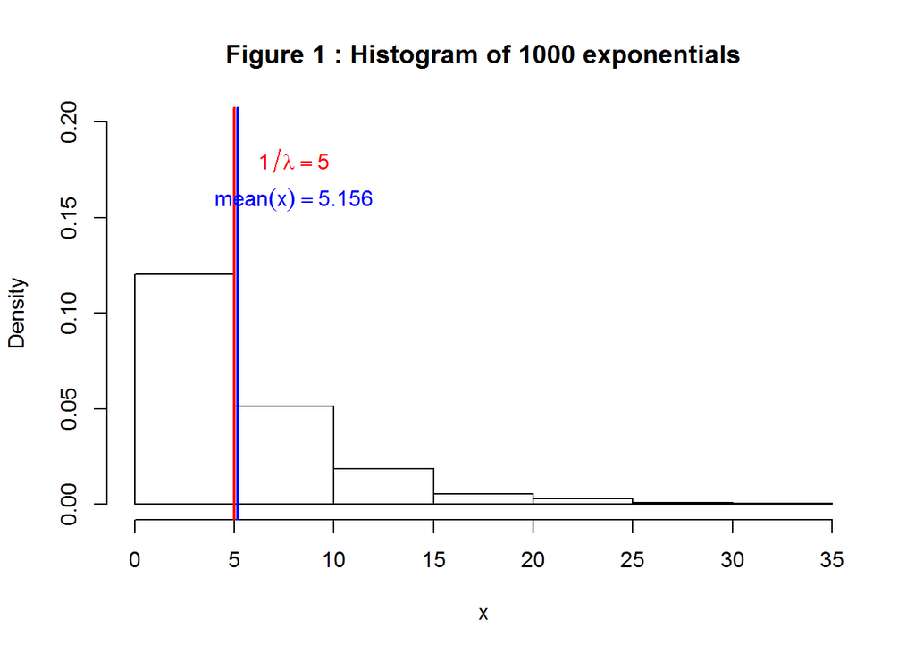

```r
set.seed(1)
lambda = 0.2
x <-rexp(1000, rate =lambda)
hist(x,main="Figure 1 : Histogram of 1000 exponentials",xlim=c(0,35),ylim=c(0,0.2),freq=FALSE)
abline(v=mean(x),col="blue", lwd=2)
abline(v=1/lambda,col="red", lwd=2)
text(8,0.18,expression(1/lambda== 5), col="red")
text(8,0.16,expression(mean(x) ==5.156), col="blue")
```

```r
print(mean(x))
```

```
## [1] 5.156513
```

```r
print(sd(x))
```

```
## [1] 4.946295
```

```r
print(var(x))
```

```
## [1] 24.46583
```

Let us compare the theoritical values and the real values obtained for this sample :

- Mean : theoritical = 1/${\lambda}$ = 5, real value = mean(x) = 5.156513, **disparity = 3.13%**
- Standard deviation : theoritical = 1/${\lambda}$ = 5, real value = sd(x) = 4.94629, **disparity = -1.07%**
- Variance : theoritical = 1/${\lambda}^2$ = 25, real value = var(x) = 24.464583, **disparity = -2.14%**